# Red de regulación transripcional

María Fernanda Martínez García

22/3/2022

Primero se debe cargar la libreria para realizar la red:

```r
library (BoolNet)
```

*A) Escribe las tablas de verdad de las reglas* Tabla de A

| B | A |
| --- | --- |
| 0 | 0 |
| 1 | 1 |

Tabla de B

| B | D | B AND NOT D |
| --- | --- | --- |
| 0 | 0 | 0 |
| 0 | 1 | 0 |
| 1 | 0 | 1 |
| 1 | 1 | 0 |

Tabla de C

| E | A | C | E OR A AND C |
| --- | --- | --- | --- |
| 0 | 0 | 0 | 0 |
| 1 | 0 | 0 | 1 |
| 1 | 1 | 0 | 1 |
| 1 | 1 | 1 | 1 |
| 0 | 1 | 0 | 0 |
| 0 | 1 | 1 | 1 |
| 0 | 0 | 1 | 0 |

Tabla de D

| B | NOT B |
| --- | --- |
| 1 | 0 |
| 0 | 1 |

Tabla de E

| D | A | D AND NOT A |
| --- | --- | --- |
| 0 | 0 | 0 |
| 1 | 0 | 1 |
| 0 | 1 | 0 |
| 1 | 1 | 0 |

Tabla de F

| B | C | B OR C |
| --- | --- | --- |
| 0 | 0 | 0 |
| 1 | 0 | 1 |
| 0 | 1 | 1 |
| 1 | 1 | 1 |

Notitas: las tablas las escribi con: https://www.tablesgenerator.com/markdown_tables :)

*B) Escribe las reglas para generar una red de tipo Boolnet*

targets, factors

A, B

B, B & !D

C, E | A & C

D, !B

E, D & !A

F, B | C

*Genera una red booleana:*

```r
red_boo <- loadNetwork ("red_reglas.txt")
red_boo
```

```
## Boolean network with 6 genes
##
## Involved genes:
## A B C D E F
##
## Transition functions:
## A = B
## B = B & !D
## C = E | A & C
## D = !B
## E = D & !A
## F = B | C
```

En un archivo de texto plano (en este caso, bloc de notas), escribí las reglas para generar la red, tal como enseñe antes.

Donde el nombre de los genes los coloque en targets (A,B,C, D, E y F)y en factor la regla por lineas usando operadores donde:

AND en R se escribe: &

OR en R se escribe: |

NOT en R se escribe: !

Mientras que la funcion loadNetwork convierte esas reglas en una red booleana, que es con la que vamos a trabajar.

*C) Encuentra todos los atractores de tu red*

```r
atract <- getAttractors (network = red_boo)
atract
```

```
## Attractor 1 is a simple attractor consisting of 1 state(s) and has a basin of 48 state(s):
##
##  |--<-----|
##  V        |
##  001111   |
##  V        |
##  |-->-----|
##
##
## Genes are encoded in the following order: A B C D E F
##
## Attractor 2 is a simple attractor consisting of 1 state(s) and has a basin of 6 state(s):
##
##  |--<-----|
##  V        |
##  110001   |
##  V        |
##  |-->-----|
##
##
## Genes are encoded in the following order: A B C D E F
##
## Attractor 3 is a simple attractor consisting of 1 state(s) and has a basin of 10 state(s):
##
##  |--<-----|
##  V        |
##  111001   |
##  V        |
##  |-->-----|
##
##
## Genes are encoded in the following order: A B C D E F
```

Esta funcion identifica a los atractores en la red booleana anterior.

*D) ¿Cuál sería el estado final más probable?*

El final más probable se conoce con los atractores. En este caso hay tres opciones: la primera es que el atractor 1 con una cuenca de atracción de 48 estados, el atractor 2 con una cuenca de atracción de 6 estados y el atractor 3 con una cuenca de atracción de 10 estados.

*E) Dibuja todos los estados y sus atractores*

La primer función hace una gráfica de los atractores; mientras que la segunda sobre los estados.

Para leer se observa de forma horizontal, donde la primer columna es el primer estado y así sucesivamente, con las demas columnas.

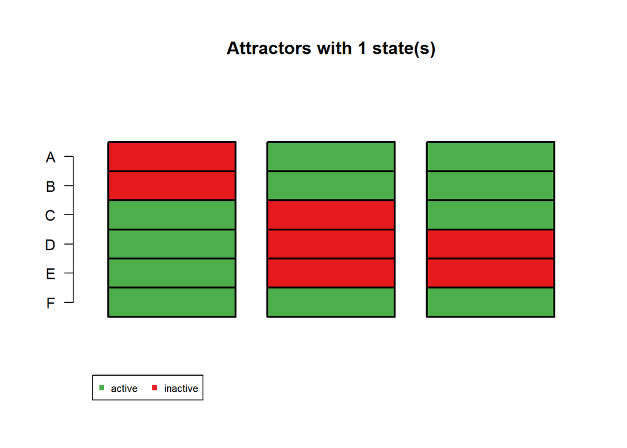

```
## $`1`
##   Attr1.1 Attr2.1 Attr3.1
## A       0       1       1
## B       0       1       1
## C       1       0       1
## D       1       0       0
## E       1       0       0
## F       1       1       1
```

```r
plotAttractors (atract)
```

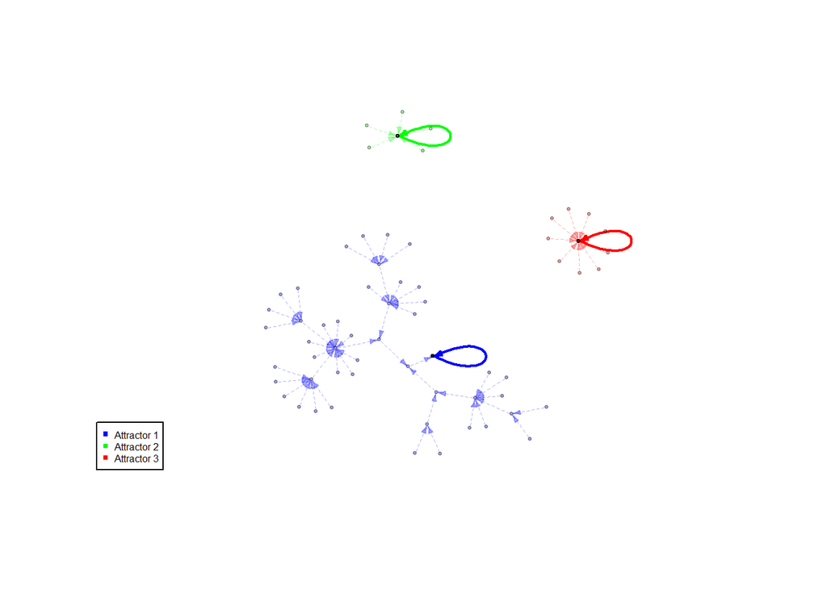

```r
plotStateGraph (atract)
```